# Practical Machine Learning Assignment

Pankaj Sharma

7 November 2015

This is an assignment of coursera Pratical Machine Learning Course.Here we are using Random Forests for modelling the data.We also set seed to make program reproductible.We use library doParallel apart from caret already shown in course.We use library pROC for plotting the ROC curve.We use package randomForest for random forests.

```r
options(warn=-1)
library(caret)
library(doParallel)
library(randomForest)
library(pROC)
```

First Step is to read CSV training file

```r
set.seed(123)

training<-read.csv("D:/pml-training.csv",header=TRUE)
```

Seperating class feature from training

```r
X.train<-training

Y.train =training[,length(training)]
```

Checking for NA’s in data and filling them with mean if feature is numeric Forcing Features which are factors as numeric and replacing #DIV/0! as factor 2

```r
for(i in 1:ncol(X.train))
{

if (class(X.train[,i])== 'integer' | class(X.train[,i])== 'numeric' )
  {
meanXi=mean(X.train[,i],na.rm=TRUE)
   for(j in 1:nrow(X.train))
     {
      if(is.na(X.train[j,i]))
        X.train[j,i]= meanXi

       }
}
if(class(X.train[,i])== 'factor')
  X.train[,i]=as.numeric(X.train[,i])

}
```

Now converting back the last column of class as factor again

```r
X.train[,ncol(X.train)]<-as.factor(X.train[,ncol(X.train)])
```

Removing columns which dont have complete observations

```r
featuresnames <- colnames(X.train[colSums(is.na(X.train)) == 0])[-(1:7)]
features <- X.train[featuresnames]
```

```r
xdata <- createDataPartition(y=features$classe, p=3/4, list=FALSE )
training <- features[xdata,]
testing <- features[-xdata,]
```

Registering with doParallel library and making a cluster of 3 cores

```r
require(doParallel)

registerDoParallel(cores=detectCores(all.tests=TRUE))

cores <- detectCores()
cl <- makePSOCKcluster(3)
registerDoParallel(cl)
```

Fitting random Forests in parallel with a total of 600 trees

```r
fit.rf <- foreach(ntree=rep(200, 3), .combine=combine,
                  .packages="randomForest") %dopar% {
  randomForest(training[,-ncol(training)], training$classe, importance = TRUE, ntree = ntree)
}
```

```r
head(importance(fit.rf, type=2))
```

```
##                     MeanDecreaseGini
## roll_belt                760.2244864
## pitch_belt               430.8657147
## yaw_belt                 573.5603466
## total_accel_belt         191.0753056
## kurtosis_roll_belt         0.2975531
## kurtosis_picth_belt        0.1794867
```

```r
stopCluster(cl)
```

Printing confusion matrix with the training data.Insample error is too low.

```r
rf.pred <- predict(fit.rf,training, type="class")
rf.perf <- table(training$classe,rf.pred ,dnn=c("Actual", "Predicted"))
confusionMatrix(rf.perf)
```

```
## Confusion Matrix and Statistics
##
##       Predicted
## Actual    1    2    3    4    5
##      1 4185    0    0    0    0
##      2    0 2848    0    0    0
##      3    0    0 2567    0    0
##      4    0    0    0 2412    0
##      5    0    0    0    0 2706
##
## Overall Statistics
##
##                Accuracy : 1
##                  95% CI : (0.9997, 1)
##     No Information Rate : 0.2843
##     P-Value [Acc > NIR] : < 2.2e-16
##
##                   Kappa : 1
##  Mcnemar's Test P-Value : NA
##
## Statistics by Class:
##
##                      Class: 1 Class: 2 Class: 3 Class: 4 Class: 5
## Sensitivity            1.0000   1.0000   1.0000   1.0000   1.0000
## Specificity            1.0000   1.0000   1.0000   1.0000   1.0000
## Pos Pred Value         1.0000   1.0000   1.0000   1.0000   1.0000
## Neg Pred Value         1.0000   1.0000   1.0000   1.0000   1.0000
## Prevalence             0.2843   0.1935   0.1744   0.1639   0.1839
## Detection Rate         0.2843   0.1935   0.1744   0.1639   0.1839
## Detection Prevalence   0.2843   0.1935   0.1744   0.1639   0.1839
## Balanced Accuracy      1.0000   1.0000   1.0000   1.0000   1.0000
```

```r
rf.pred <- predict(fit.rf,testing, type="class")
rf.perf <- table(testing$classe,rf.pred ,dnn=c("Actual", "Predicted"))
rf.perf
```

```
##       Predicted
## Actual    1    2    3    4    5
##      1 1394    1    0    0    0
##      2    2  945    2    0    0
##      3    0    8  846    1    0
##      4    0    0   12  790    2
##      5    0    0    0    1  900
```

```r
confusionMatrix(rf.perf)
```

```
## Confusion Matrix and Statistics
##
##       Predicted
## Actual    1    2    3    4    5
##      1 1394    1    0    0    0
##      2    2  945    2    0    0
##      3    0    8  846    1    0
##      4    0    0   12  790    2
##      5    0    0    0    1  900
##
## Overall Statistics
##
##                Accuracy : 0.9941
##                  95% CI : (0.9915, 0.996)
##     No Information Rate : 0.2847
##     P-Value [Acc > NIR] : < 2.2e-16
##
##                   Kappa : 0.9925
##  Mcnemar's Test P-Value : NA
##
## Statistics by Class:
##
##                      Class: 1 Class: 2 Class: 3 Class: 4 Class: 5
## Sensitivity            0.9986   0.9906   0.9837   0.9975   0.9978
## Specificity            0.9997   0.9990   0.9978   0.9966   0.9998
## Pos Pred Value         0.9993   0.9958   0.9895   0.9826   0.9989
## Neg Pred Value         0.9994   0.9977   0.9965   0.9995   0.9995
## Prevalence             0.2847   0.1945   0.1754   0.1615   0.1839
## Detection Rate         0.2843   0.1927   0.1725   0.1611   0.1835
## Detection Prevalence   0.2845   0.1935   0.1743   0.1639   0.1837
## Balanced Accuracy      0.9991   0.9948   0.9907   0.9970   0.9988
```

Plotting the ROC curve with the sensitivity and specificity thresholds.It showed that area under curve was very close to best prediction.

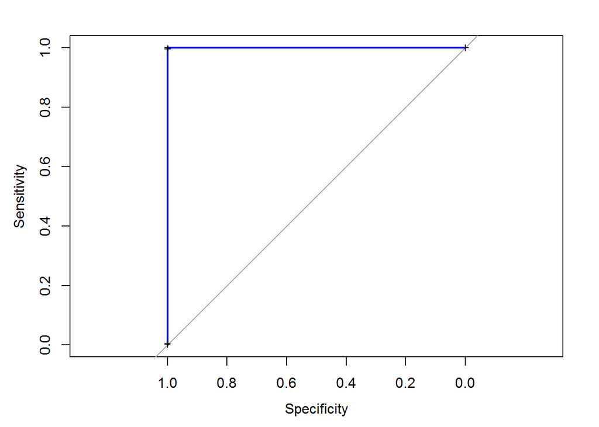

```
##
## Call:
## plot.roc.default(x = testing$classe, predictor = rf.pred, ci = TRUE,     of = "thresholds", type = "shape", col = "blue")
##
## Data: rf.pred in 1395 controls (testing$classe 1) < 949 cases (testing$classe 2).
## Area under the curve: 0.9986
## 95% CI (2000 stratified bootstrap replicates):
##  thresholds sp.low sp.median sp.high se.low se.median  se.high
##        -Inf 0.0000    0.0000       0 1.0000  1.000000 1.000000
##         1.5 0.9978    0.9993       1 0.9947  0.997900 1.000000
##         2.5 1.0000    1.0000       1 0.0000  0.002107 0.005269
```

Thankyou all,It was fun doing this assignment.